# Estadistica descriptiva y normalizacion de datos

# Introduccion

Ahora que ya sabemos como procesar y modificar nuestras tablas, es momento de aplicar todo lo aprendido a una de las bases del metodo cientifico: **el analisis estadistico**

Si bien hay muchas maneras de analizar datos y aun mas metodos para ello. A lo largo de este modulo vamos a aprender un flujo basico para determinar que tipo de analisis es el mas idoneo para cada tipo de datos.

```r
Acidos <- read.csv("~/Capacitaciones/RStudio/curso_innovak/Material de trabajo/Acidos_ex.csv")
```

```
Error: inesperado '/' in:
"
Acidos <- read.csv("~/"
```

# Estadistica descriptiva

En la clase anterior ya vimos, los valores mas importantes dentro de la estadistica descriptiva. El objetivo de la estadística descriptiva es describir los datos observados de forma sintética y significativa para poder analizarlos mejor. La estadística descriptiva comprende tres categorías principales:

1. Distribución de frecuencias
   - Count: n(), n_distinct() en dplyr o count()
   - Range: min(), max(), quantile()
2. Medidas de tendencia central
   - Center: mean(), median()
3. Medidas de variabilidad.
   - Spread: sd(), IQR(), mad()

```r
mean(medidas_clase$Height.cm) # i tienes celdas vacias no olvides el na.rm = TRUE
```

```
[1] 169.1847
```

```r
median(medidas_clase$Height.cm)
```

```
[1] 167.62
```

```r
# 3. Variabilidad
sd(medidas_clase$Height.cm)
```

```
[1] 10.57371
```

```r
IQR(medidas_clase$Height.cm)
```

```
[1] 15.585
```

```r
mad(medidas_clase$Height.cm)
```

```
[1] 11.26776
```

## Ejercicio

Usando el dataframe de *plantas* sacar la estadistica descriptiva de *Root Area*.

```r
mean(Plantas$root_area, na.rm = TRUE)
```

```
[1] 1225.294
```

```r
median(Plantas$root_area, na.rm = TRUE)
```

```
[1] 1207.878
```

```r
sd(Plantas$root_area, na.rm = TRUE)
```

```
[1] 939.2711
```

```r
mad(Plantas$root_area, na.rm = TRUE)
```

```
[1] 1075.77
```

# Normalizacion de datos

La distribucion normal de datos se caracteriza por gran cantidad de datos alrededor de la media y pocos datos en las colas de forma **Simetrica**.

Es decir si conocemos la media y la desviacion estandar son conocidos la probabilidad de que cualquier observacion futura caiga dentro de un rango especifo ya es conocida

Todos los analisis parametricos tiene como primera suposicion que los datos que se van a usar en el analisis siguen una distribucion normal e ahi la importancia de normalizar los datos.

## Como saber si nuestros datos son normales

```r
# Shapiro-wilk
shapiro.test(Stream$Temp.degC)
```

```
    Shapiro-Wilk normality test

data:  Stream$Temp.degC
W = 0.97518, p-value = 0.0856
```

## Ejercicio de normalidad

```r
par(mfrow = c(1,2))
hist(Plantas$root_area)
qqnorm(Plantas$root_area)

shapiro.test(Plantas$root_area)
```

[output not shown]

```
    Shapiro-Wilk normality test

data:  Plantas$root_area
W = 0.93009, p-value = 0.006868
```

# EJercicios

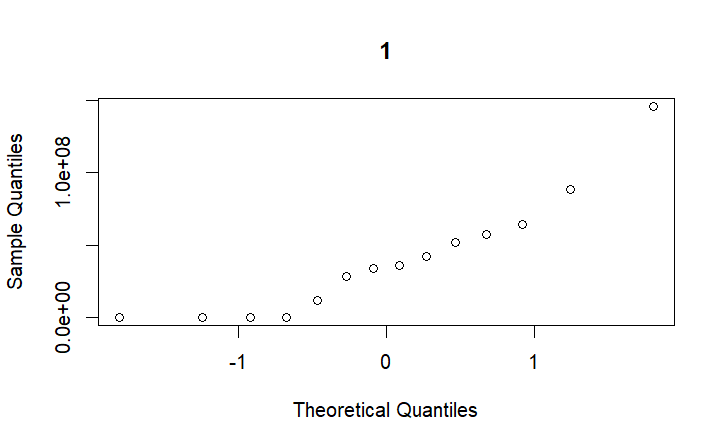

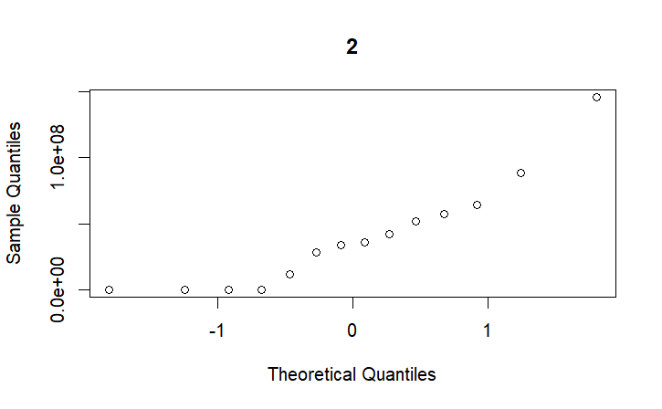

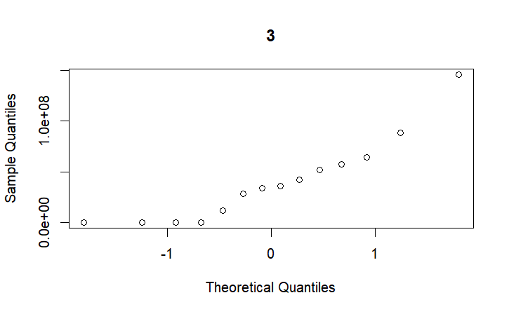

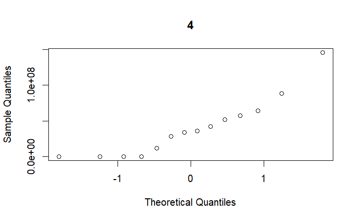

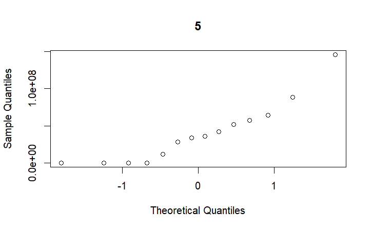

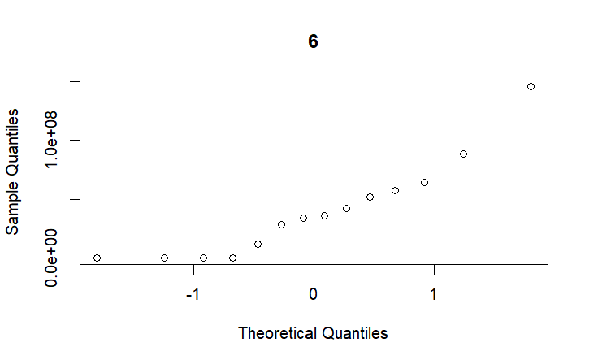

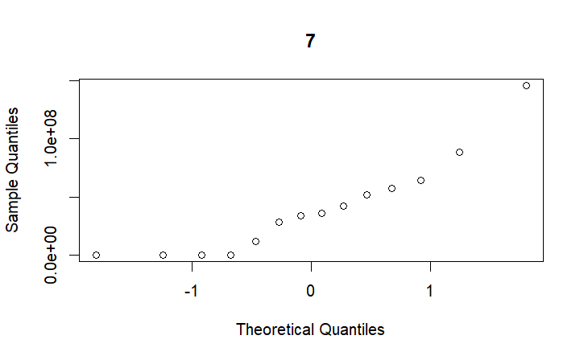

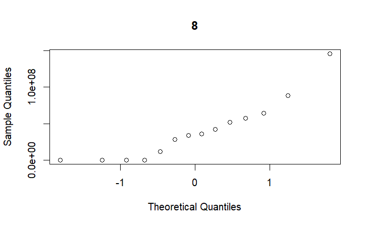

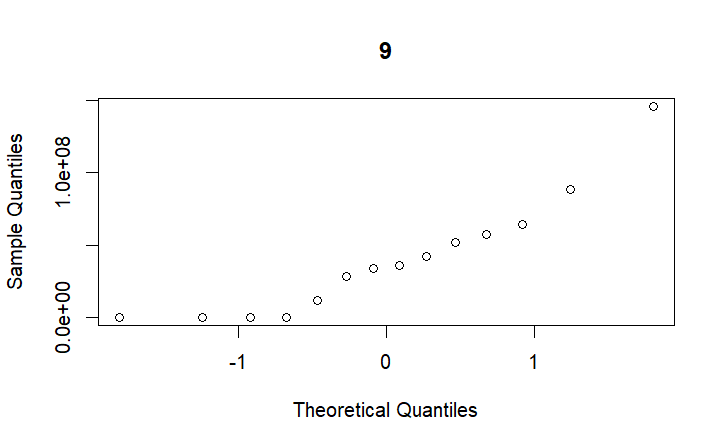

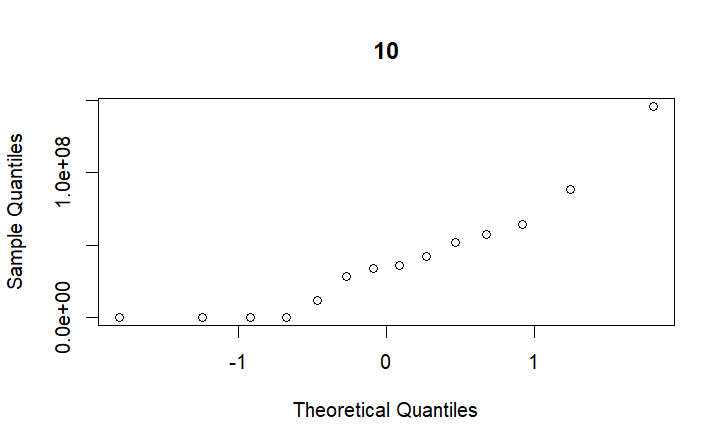

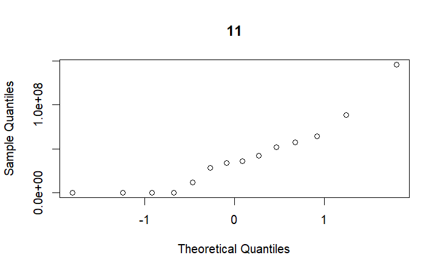

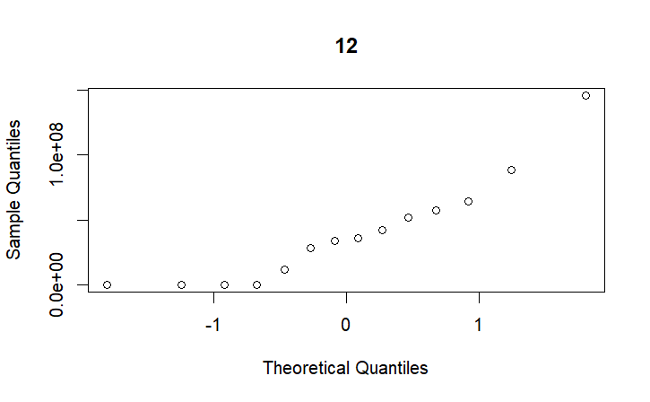

[3 more figures not shown]

# Ejercicio

```r
for (i in 6:ncol(Plantas)){
  shapiro <- shapiro.test(Plantas[,i])
  normal <- ifelse(shapiro[["p.value"]] > 0.05, "YES", "NO")
  print(c(i, normal))
}
```

```
[1] "6"  "NO"
[1] "7"  "NO"
[1] "8"  "NO"
[1] "9"  "NO"
[1] "10" "NO"
[1] "11"  "YES"
[1] "12" "NO"
[1] "13" "NO"
[1] "14"  "YES"
[1] "15"  "YES"
[1] "16"  "YES"
```

```r
for (i in 1:ncol(Acidos)) {
  Acid_log[,i] <- abs(log(Acidos[,i])) # abs valor absoluto
}
```

```
Error in log(Acidos[, i]) : non-numeric argument to mathematical function
```